# An Introduction to SimpleUpset

```r
library(tidyverse)
library(SimpleUpset)
library(pander)
theme_set(theme_bw())
```

The package `SimpleUpset` has been written to ensure that UpSet plots (Lex et al. 2014) remain consistently available to the ecosystem of `R` users. The underlying functions are built depending heavily on the package infrastructure provided by the `tidyverse` (Wickham et al. 2019).

A modified version of the `movies` data will be used for this set of examples, based on the file originally provided in the package `UpSetR` (Gehlenborg 2019). This version of the data has a reduced number of categories and also has the decade of release included.

```r
movies <- system.file("extdata", "movies.tsv.gz", package = "SimpleUpset") %>%
  read_tsv() %>%
  mutate(
    Decade = fct_inorder(Decade) %>% fct_rev()
  )
```

Summary of movies by decade

| Decade | n |
| --- | --- |
| 1991-2000 | 2362 |
| 1981-1990 | 634 |
| 1971-1980 | 272 |
| 1961-1970 | 192 |
| 1951-1960 | 169 |
| 1941-1950 | 121 |
| 1931-1940 | 89 |
| 1921-1930 | 39 |
| 1911-1920 | 5 |

## Basic Usage

At it’s most simple, the function `simpleUpSet` requires a data.frame with sets to include for display using the UpSet plots. The sets should be strictly `0/1` values which can be coerced to logical values, or logical values directly.

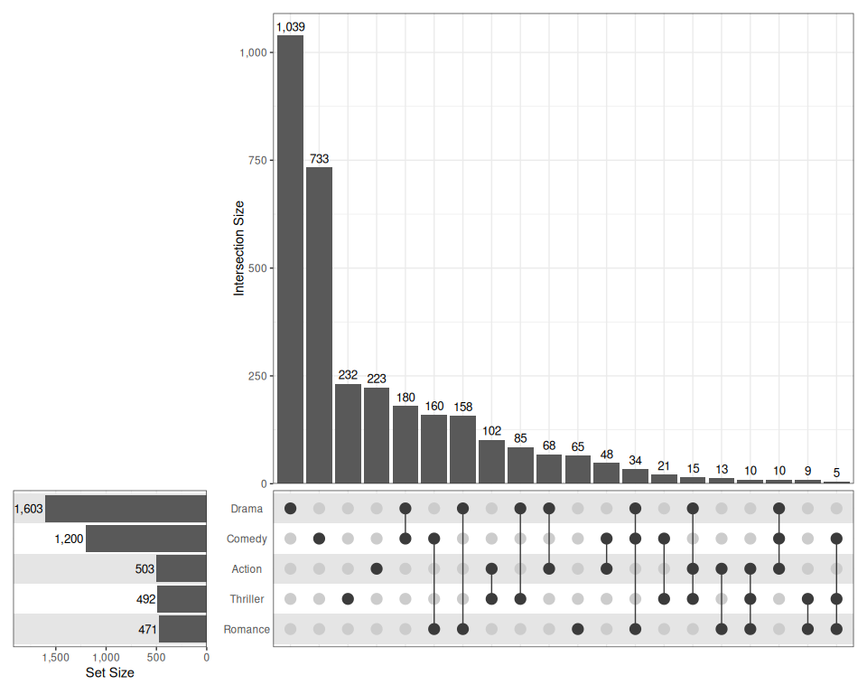

```r
sets <- c("Action", "Comedy", "Drama", "Thriller", "Romance")
simpleUpSet(movies, sets)
```

The number of intersections can be controlled using the arguments `n_intersect` to define a maximum number plotted, or `min_size` to only show those greater than any given size.

## Customising Plots

Each of the panels in the complete UpSet figure is referred to as being either 1. `sets` (the bottom left), 2. `intersect` (the top right panel), or 3. `grid`, representing the intersections matrix at the bottom right. Default layers for each panel are produced by the functions `default_set_layers()`, `default_intersect_layers()` or `default_grid_layers()`. The default calls to ggplot layers, scales, themes etc are easily visible by passing the argument, `dry_run = TRUE`. These can then be copied to a new object to begin customisation from a low level.

```r
default_set_layers(dry_run = TRUE)
```

```
#> list(aes(y = set), geom_bar(aes(fill = ~NULL)), geom_text(aes(x = size,
#>     label = f(size)), hjust = hjust, vjust = vjust, angle = angle,
#>     size = label_size, fontface = fontface, lineheight = lineheight),
#>     scale_x_reverse(expand = expansion(expand), name = name,
#>         labels = comma), scale_y_discrete(position = "right",
#>         name = NULL, labels = NULL), theme(axis.text.y.right = element_text(hjust = 0.5),
#>         axis.ticks.y.right = element_blank(), margins = margin(5.5,
#>             0, 5.5, 5.5)))
```

A more simple strategy is to pass a set of key parameters to each function as described on the help page. Any additional layers are handled simply by the ellipsis (`...`).

```r
simpleUpSet(
  movies, sets, min_size = 20,
  intersect_layers = default_intersect_layers(
    fill = "Decade",
    scale_fill_brewer(palette = "Paired"),
    theme(
      legend.position = "inside",
      legend.position.inside = c(0.99, 0.99),
      legend.justification.inside = c(1, 1)
    )
  ),
  set_layers = default_set_layers(
    fill = "Decade", scale_fill_brewer(palette = "Paired"),
    guides(fill = guide_none()), expand = c(0.3, 0)
  )
)
```

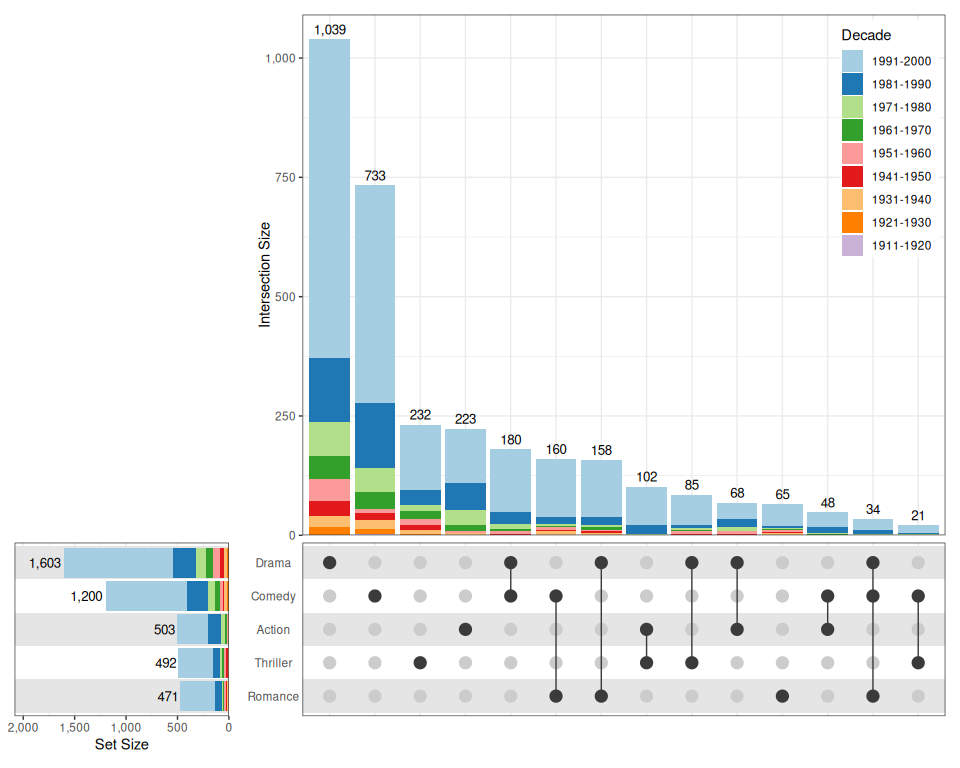

## Highlighting Intersections and Sets

Sets and intersections can be simply highlighted using the set name for sets, or by using a `case_when()` statement to define highlights. If the highlight column is added to the underlying data object, this column can additionally be used for determining intersection order.

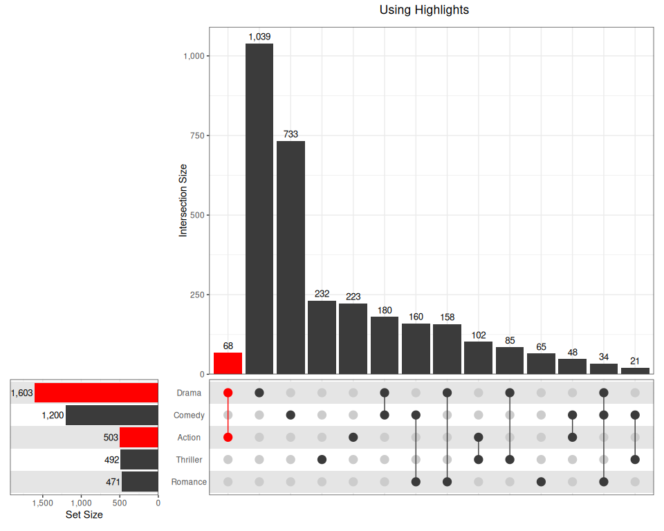

```r
## Define the sets to be coloured by name, the use scale_fill_manual
set_cols <- c(
  Action = "red", Comedy = "grey23", Drama = "red",
  Romance = "grey23", Thriller = "grey23"
)
set_list <- default_set_layers(fill = "set", scale_fill_manual(values = set_cols))
## Use the highlights to colour the intersection bars based on the column
## 'highlight', in conjunction with the case_when statement
intersect_list <- default_intersect_layers(
    fill = "highlight", scale_fill_manual(values = "red", na.value = "grey23")
  )
## When passing the 'highlight' column, this will be passed to both points
## and segments. Each layer can be manually edited to override this if preferred
grid_list <- default_grid_layers(
  colour = "highlight", scale_colour_manual(values = "red", na.value = "grey23")
)
simpleUpSet(
  movies, sets, min_size = 20,
  set_layers = set_list,
  intersect_layers = intersect_list,
  grid_layers = grid_list,
  sort_intersect = list(highlight, desc(size)),
  highlight = case_when(Action & Drama ~ TRUE)
) &
  plot_annotation(title = "Using Highlights") &
  theme(legend.position = "none", plot.title = element_text(hjust = 2/3))
```

Alternatively, the complete set of intersections containing any one of the sets can be highlighted simply by filling bars using that individual set.

```r
simpleUpSet(
  movies, sets, min_size = 20,
  intersect_layers = default_intersect_layers(
    fill ="Comedy",
    scale_fill_manual(values = c("grey23", "blue")),
    guides(fill = guide_none())
  ),
  grid_layers = default_grid_layers(
    colour = "Comedy", scale_colour_manual(values = c("grey23", "blue"))
  )
)
```

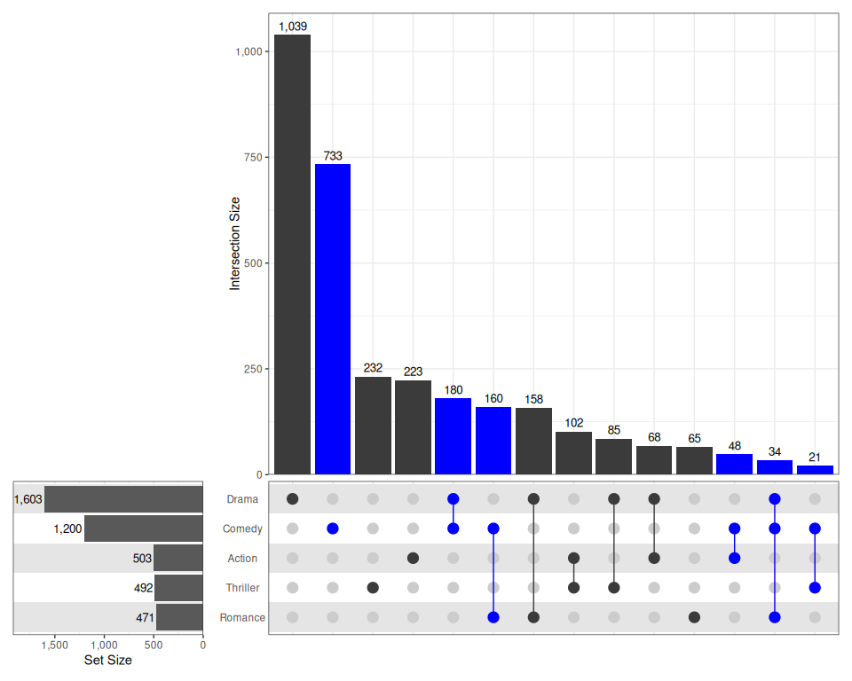

## Adding Plots to Upper Panels

Additional panels can be included using the `annotations` argument.

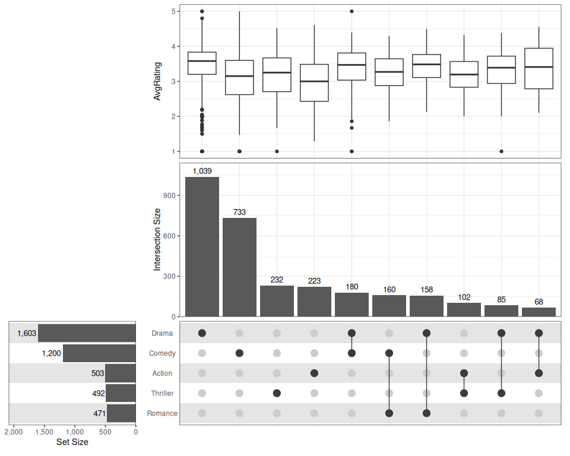

```r
## Add a simple boxplot
simpleUpSet(
  movies, sets, n_intersect = 10,
  set_layers = default_set_layers(expand = c(0.3, 0)),
  intersect_layers = default_intersect_layers(expand = c(0, 0.1)),
  annotations = list(geom_boxplot(aes(y = AvgRating))),
)
```

There is no particular limit to the complexity of the upper panels, beyond what is contained within the dataset, or what can be considered as useful for communication with readers.

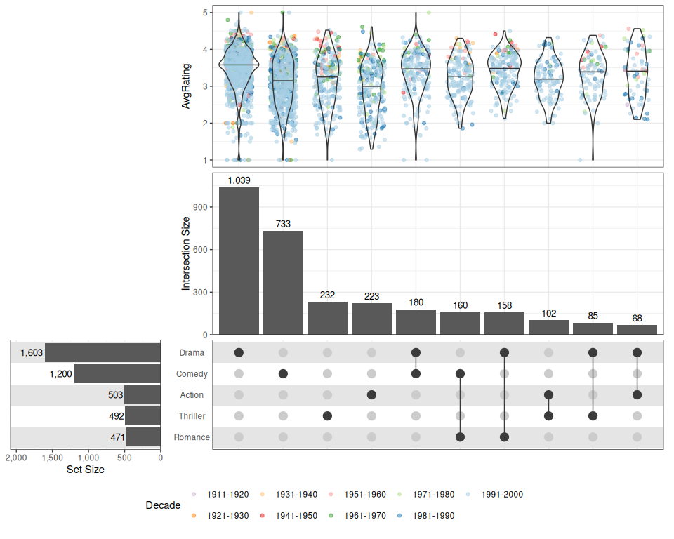

```r
simpleUpSet(
  movies, sets, n_intersect = 10,
  set_layers = default_set_layers(expand = c(0.3, 0)),
  intersect_layers = default_intersect_layers(expand = c(0, 0.1)),
  annotations = list(
    list(
      aes(y = AvgRating),
      geom_jitter(aes(colour = Decade), height = 0, width = 0.3, alpha = 0.5),
      geom_violin(fill = NA, quantiles = 0.5, quantile.linetype = 1),
      scale_colour_brewer(palette = "Paired"),
      guides(colour = guide_legend(nrow = 2, reverse = TRUE))
    )
  ), guides = "collect"
) &
  theme(legend.position = "bottom")
```

## SessionInfo

**R version 4.6.1 (2026-06-24)**

**Platform:** x86_64-pc-linux-gnu

**locale:** *LC_CTYPE=en_US.UTF-8*, *LC_NUMERIC=C*, *LC_TIME=en_US.UTF-8*, *LC_COLLATE=C*, *LC_MONETARY=en_US.UTF-8*, *LC_MESSAGES=en_US.UTF-8*, *LC_PAPER=en_US.UTF-8*, *LC_NAME=C*, *LC_ADDRESS=C*, *LC_TELEPHONE=C*, *LC_MEASUREMENT=en_US.UTF-8* and *LC_IDENTIFICATION=C*

**attached base packages:** *stats*, *graphics*, *grDevices*, *utils*, *datasets*, *methods* and *base*

**other attached packages:** *pander(v.0.6.6)*, *SimpleUpset(v.0.1.5)*, *patchwork(v.1.3.2)*, *lubridate(v.1.9.5)*, *forcats(v.1.0.1)*, *stringr(v.1.6.0)*, *dplyr(v.1.2.1)*, *purrr(v.1.2.2)*, *readr(v.2.2.0)*, *tidyr(v.1.3.2)*, *tibble(v.3.3.1)*, *ggplot2(v.4.0.3)* and *tidyverse(v.2.0.0)*

**loaded via a namespace (and not attached):** *sass(v.0.4.10)*, *generics(v.0.1.4)*, *stringi(v.1.8.7)*, *hms(v.1.1.4)*, *digest(v.0.6.39)*, *magrittr(v.2.0.5)*, *evaluate(v.1.0.5)*, *grid(v.4.6.1)*, *timechange(v.0.4.0)*, *RColorBrewer(v.1.1-3)*, *fastmap(v.1.2.0)*, *jsonlite(v.2.0.0)*, *scales(v.1.4.0)*, *jquerylib(v.0.1.4)*, *cli(v.3.6.6)*, *crayon(v.1.5.3)*, *rlang(v.1.2.0)*, *bit64(v.4.8.2)*, *withr(v.3.0.3)*, *cachem(v.1.1.0)*, *yaml(v.2.3.12)*, *otel(v.0.2.0)*, *parallel(v.4.6.1)*, *tools(v.4.6.1)*, *tzdb(v.0.5.0)*, *vctrs(v.0.7.3)*, *R6(v.2.6.1)*, *lifecycle(v.1.0.5)*, *bit(v.4.6.0)*, *vroom(v.1.7.1)*, *pkgconfig(v.2.0.3)*, *pillar(v.1.11.1)*, *bslib(v.0.11.0)*, *gtable(v.0.3.6)*, *glue(v.1.8.1)*, *Rcpp(v.1.1.1-1.1)*, *xfun(v.0.59)*, *tidyselect(v.1.2.1)*, *rstudioapi(v.0.19.0)*, *knitr(v.1.51)*, *dichromat(v.2.0-0.1)*, *farver(v.2.1.2)*, *htmltools(v.0.5.9)*, *labeling(v.0.4.3)*, *rmarkdown(v.2.31)*, *compiler(v.4.6.1)* and *S7(v.0.2.2)*

## References

Gehlenborg, Nils. 2019. *UpSetR: A More Scalable Alternative to Venn and Euler Diagrams for Visualizing Intersecting Sets*. https://doi.org/10.32614/CRAN.package.UpSetR.

Lex, Alexander, Nils Gehlenborg, Hendrik Strobelt, Romain Vuillemot, and Hanspeter Pfister. 2014. “UpSet: Visualization of Intersecting Sets.” *IEEE Transactions on Visualization and Computer Graphics* 20 (12): 1983–92. https://doi.org/10.1109/TVCG.2014.2346248.

Wickham, Hadley, Mara Averick, Jennifer Bryan, et al. 2019. “Welcome to the tidyverse.” *Journal of Open Source Software* 4 (43): 1686. https://doi.org/10.21105/joss.01686.